# Sentiment Finance

Hairul Yasin

# 1 Pendahuluan

Laporan ini bertujuan untuk mengklasifikasikan sentimen pada data teks terkait dengan layanan keuangan. Tujuan utama laporan ini adalah untuk menganalisis dan memodelkan sentimen yang terkandung dalam data teks, sehingga dapat memprediksi dengan akurat sentimen yang muncul, seperti positif, negatif terhadap layanan keuangan.

## 1.1 Latar Belakang

Sentimen pelanggan dalam industri layanan keuangan memiliki peran yang sangat penting. Perasaan positif atau negatif pelanggan dapat memengaruhi reputasi perusahaan, keputusan investasi, dan kepuasan pelanggan secara keseluruhan. Oleh karena itu, memahami sentimen yang terkandung dalam data teks pelanggan sangat berharga.

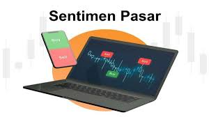

## 1.2 Tujuan

Tujuan dari pembuatan laporan ini adalah untuk mengklasifikasikan sentimen dari data teks yang berkaitan dengan layanan keuangan. Dalam laporan ini, kami akan menggunakan teknik pemrosesan teks dan pemodelan yang sesuai untuk menganalisis data teks yang ada. Beberapa target dan prediktor yang mungkin kami gunakan untuk mencapai tujuan ini adalah:

- Target : `label`.
- Prediktor : *Semua variabel*, `kecuali label`.

# 2 Read Data

Dalam bagian ini, kita akan membaca data dan melakukan proses pembersihan (jika diperlukan).

## 2.1 Memuat dataset latih dan dataset uji

Pertama, kita akan memuat dataset latih dan dataset uji yang akan digunakan dalam analisis. Dataset latih akan digunakan untuk melatih model dan dataset uji akan digunakan untuk menguji performa model yang telah dilatih.

```r
data1 <- read.csv("train_data.csv")
data2 <- read.csv("test_data.csv")

# Menggabungkan train_data dan test_data menjadi satu dataset
train_data <- rbind(data1, data2)
```

# 3 Exploratory Data Analysis

## 3.1 Mengeksplorasi struktur data dan variabel

Selanjutnya, kita akan melakukan eksplorasi terhadap struktur data dan variabel yang ada.

|  | label | en_text | id_text |
| --- | --- | --- | --- |
| 1 | negative | However , the growth margin slowed down due to the financial crisis . | Namun, margin pertumbuhan melambat akibat krisis keuangan. |
| 2 | positive | Bilfinger investors cheered the agreement , pushing shares up 7 % , or & euro ; 3.30 , to & euro ; 50.29 , in afternoon trade . | Investor Bilfinger menyambut baik kesepakatan tersebut, mendorong saham naik 7%, atau & euro; 3.30 , ke & euro ; 50.29, pada perdagangan sore. |
| 3 | positive | Following the acquisition , Relacom will strengthen its presence in Finland , serving operators and office market with mobile and fixed networks construction , installation and maintenance services . | Setelah akuisisi, Relacom akan memperkuat kehadirannya di Finlandia, melayani pasar operator dan perkantoran dengan jasa konstruksi, instalasi dan pemeliharaan jaringan bergerak dan tetap. |
| 4 | negative | Profit before taxes amounted to EUR 56.5 mn , down from EUR 232.9 mn a year ago . | Laba sebelum pajak berjumlah EUR 56,5 juta, turun dari EUR 232,9 juta tahun lalu. |
| 5 | positive | In the third quarter , net sales increased by 12 % year-on-year to EUR159 .5 m , or by 6 % at comparable currency rates growth . | Pada kuartal ketiga, penjualan bersih meningkat sebesar 12% tahun-ke-tahun menjadi EUR159,5 juta, atau sebesar 6% pada pertumbuhan nilai tukar mata uang yang sebanding. |
| 6 | positive | Finnish plumbing and heating systems supplier Uponor Corporation ( OMX Helsinki : UNR1V ) said on Tuesday ( 12 August ) that its board of directors has authorised the management to proceed with a comp… | Pemasok sistem pipa dan pemanas Finlandia Uponor Corporation (OMX Helsinki: UNR1V) mengatakan pada hari Selasa (12 Agustus) bahwa dewan direksi telah memberi wewenang kepada manajemen untuk melanjutka… |

- *label* : Merupakan label Positive/Negative untuk setiap artikel
- *en_text* : Berisi konten artikel dalam bahasa ingris.
- *id_text* : Berisi konten artikel dalam bahasa indonesia

## 3.2 Melihat tipe data

```
## 'data.frame':    1573 obs. of  3 variables:
##  $ label  : chr  "negative" "positive" "positive" "negative" ...
##  $ en_text: chr  "However , the growth margin slowed down due to the financial crisis ." "Bilfinger investors cheered the agreement , pushing shares up 7 % , or & euro ; 3.30 , to & euro ; 50.29 , in a"| __truncated__ "Following the acquisition , Relacom will strengthen its presence in Finland , …
##  $ id_text: chr  "Namun, margin pertumbuhan melambat akibat krisis keuangan." "Investor Bilfinger menyambut baik kesepakatan tersebut, mendorong saham naik 7%, atau & euro; 3.30 , ke & euro "| __truncated__ "Setelah akuisisi, Relacom akan memperkuat kehadirannya di Finlandia, melayani pasar opera…
```

💡 Tipe datanya sudah sesuai dengan kasus kali ini, namun perlu dilakukkan penyesuaian lebih lanjut.

## 3.3 Cek missing values

Kemudian, kita akan memeriksa apakah terdapat missing values atau nilai yang hilang pada dataset. Jika ada, kita akan menangani missing values tersebut dengan melakukan imputasi atau penghapusan nilai yang hilang, sesuai dengan kebutuhan analisis kita.

```r
# Memeriksa missing values pada dataset latih
colSums(is.na(train_data))
```

```
##   label en_text id_text
##       0       0       0
```

💡 `tidak ada missing values` dalam dataset.

## 3.4 Mengeksplor variabel target

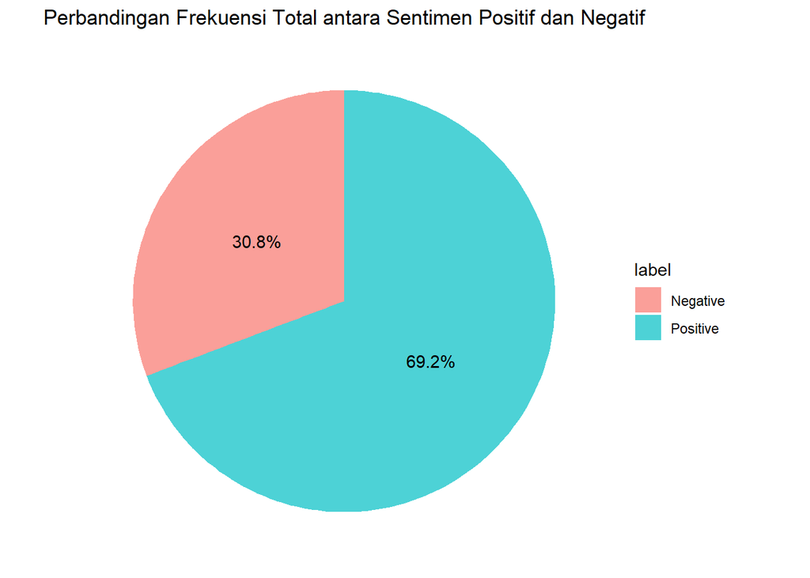

```r
# Menghitung jumlah frekuensi untuk kategori positive dan negative
positive_freq <- sum(train_data$label == "positive")
negative_freq <- sum(train_data$label == "negative")

# Menghitung persentase untuk positive dan negative
positive_percentage <- positive_freq / nrow(train_data) * 100
negative_percentage <- negative_freq / nrow(train_data) * 100

# Membuat data frame untuk pie chart
pie_data <- data.frame(Category = c("Positive", "Negative"),
                       Frequency = c(positive_freq, negative_freq),
                       Percentage = c(positive_percentage, negative_percentage))

# Membuat plot pie chart
library(ggplot2)
ggplot(pie_data, aes(x = "", y = Frequency, fill = Category)) +
  geom_bar(stat = "identity", width = 1, alpha = 0.7) +
  coord_polar("y", start = 0) +
  labs(x = NULL, y = NULL, fill = "label") +
  ggtitle("Perbandingan Frekuensi Total antara Sentimen Positif dan Negatif") +
  theme_minimal() +
  theme(axis.line = element_blank(),
        axis.text = element_blank(),
        axis.title = element_blank(),
        panel.grid = element_blank(),
        plot.title = element_text(hjust = 0.5)) +
  geom_text(aes(label = paste0(round(Percentage, 1), "%")), position = position_stack(vjust = 0.5))
```

💡 + Mayoritas sentimen dalam data adalah positif, mengindikasikan optimisme dalam lanskap finansial yang dianalisis. + Perlu memperhatikan sentimen negatif, yang bisa menjadi sumber risiko atau perhatian potensial dalam analisis finansial.

## 3.5 Menganalisis karakteristik teks terkait *negative*

kali ini saya mau melihat karakteristik teks yang terkait dengan pesan *negative* menggunakan visualisasi `wordcloud`

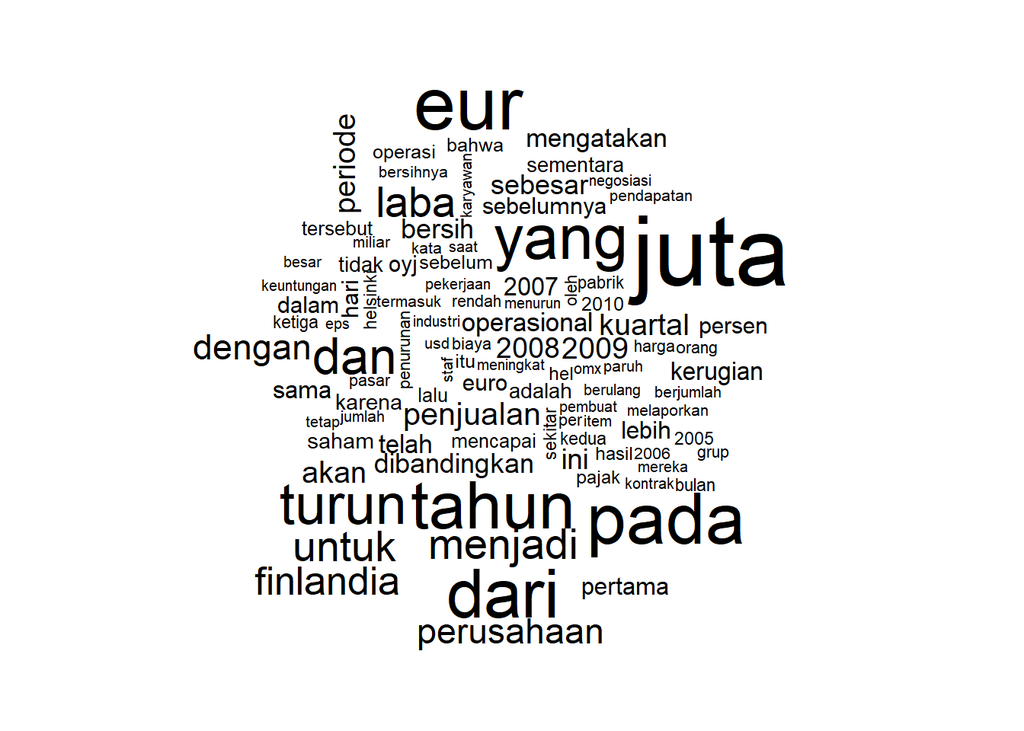

```r
# Filter data untuk kategori "negative" atau pesan berdampak buruk
negative_text <- train_data$id_text[train_data$label == "negative"]

# Menggabungkan semua teks negatif menjadi satu string
negative_text <- paste(negative_text, collapse = " ")

# Menghapus kata-kata yang tidak relevan atau umum dalam teks negatif
custom_stopwords <- c("dan", "atau", "ini", "itu", "dari", "dengan", "ke", "di", "untuk")

# Membuat wordcloud untuk teks negatif dengan batasan kata
wordcloud(negative_text, stopwords = custom_stopwords, max.words = 100)
```

# 4 Data Preprocessing

💡Dalam kasus ini, saya akan melakukan preprocesing pada kolom *id_text* menggunakan pustaka `textclean`. Preprocess data teks melibatkan langkah-langkah seperti tokenisasi, pembersihan tanda baca & emoticon, mengubah ke huruf kecil, dan lainnya untuk mempersiapkan data sebelum dilakukan analisis teks lebih lanjut.

## 4.1 Cek apakah ada emoticon dan punctuation?

```r
# Mengecek keberadaan emoticon dalam kolom "text"
has_emoticon <- any(stringr::str_detect(train_data$id_text, ":\\)|:\\(|;\\)|;\\)|:D"))

has_emoticon <- any(stringr::str_detect(train_data$en_text, ":\\)|:\\(|;\\)|;\\)|:D"))

# Mengecek keberadaan punctuation dalam kolom "text"
has_punctuation <- any(stringr::str_detect(train_data$id_text, "[[:punct:]]"))

# Output hasil pengecekan
has_emoticon
```

```
## [1] FALSE
```

```r
has_punctuation
```

```
## [1] TRUE
```

💡Setelah melakukan pengecekan pada data, tidak ditemukan adanya emotikon. Namun, ada tanda baca `punctuation` yang perlu ditangani.

## 4.2 Persiapkan paket untuk preprocessing

```r
# library(katadasaR)
library(textclean) #meembersihkan teks
library(tokenizers) #membagi teks menjadi token2
library(wordcloud) #membuat wodcloud
library(stringr) #memaipulasi teks / regex
library(tm)
head(train_data$id_text)
```

```
## [1] "Namun, margin pertumbuhan melambat akibat krisis keuangan."
## [2] "Investor Bilfinger menyambut baik kesepakatan tersebut, mendorong saham naik 7%, atau & euro; 3.30 , ke & euro ; 50.29, pada perdagangan sore."
## [3] "Setelah akuisisi, Relacom akan memperkuat kehadirannya di Finlandia, melayani pasar operator dan perkantoran dengan jasa konstruksi, instalasi dan pemeliharaan jaringan bergerak dan tetap."
## [4] "Laba sebelum pajak berjumlah EUR 56,5 juta, turun dari EUR 232,9 juta tahun lalu."
## [5] "Pada kuartal ketiga, penjualan bersih meningkat sebesar 12% tahun-ke-tahun menjadi EUR159,5 juta, atau sebesar 6% pada pertumbuhan nilai tukar mata uang yang sebanding."
## [6] "Pemasok sistem pipa dan pemanas Finlandia Uponor Corporation (OMX Helsinki: UNR1V) mengatakan pada hari Selasa (12 Agustus) bahwa dewan direksi telah memberi wewenang kepada manajemen untuk melanjutkan program pengurangan biaya di seluruh perusahaan."
```

## 4.3 Melakukan preprocess data untuk teks, langhkahnya :

- Mengubah teks menjadi huruf kecil.
- Mengganti kontraksi kata menjadi bentuk lengkap.
- Menghilangkan tanda baca dan karakter khusus dari teks, dll.

```r
# Mengubah teks menjadi huruf kecil.
preprocessed_text  <- tolower(train_data$id_text)

# Mengganti kontraksi kata menjadi bentuk lengkap.
preprocessed_text <- replace_contraction(preprocessed_text)

# Menghilangkan karakter selain alphanumeric dan spasi.
preprocessed_text <- gsub("[^[:alnum:][:space:]]", "", preprocessed_text)

# Menghilangkan tanda baca.
preprocessed_text <- gsub("[[:punct:]]", "", preprocessed_text)

# Menghilangkan angka.
preprocessed_text <- gsub("\\d+", "", preprocessed_text)

# Membersihkan teks dari karakter yang tidak diinginkan.
preprocessed_text <- strip(preprocessed_text)

head(preprocessed_text)
```

```
## [1] "namun margin pertumbuhan melambat akibat krisis keuangan"
## [2] "investor bilfinger menyambut baik kesepakatan tersebut mendorong saham naik atau euro ke euro pada perdagangan sore"
## [3] "setelah akuisisi relacom akan memperkuat kehadirannya di finlandia melayani pasar operator dan perkantoran dengan jasa konstruksi instalasi dan pemeliharaan jaringan bergerak dan tetap"
## [4] "laba sebelum pajak berjumlah eur juta turun dari eur juta tahun lalu"
## [5] "pada kuartal ketiga penjualan bersih meningkat sebesar tahunketahun menjadi eur juta atau sebesar pada pertumbuhan nilai tukar mata uang yang sebanding"
## [6] "pemasok sistem pipa dan pemanas finlandia uponor corporation omx helsinki unrv mengatakan pada hari selasa agustus bahwa dewan direksi telah memberi wewenang kepada manajemen untuk melanjutkan program pengurangan biaya di seluruh perusahaan"
```

## 4.4 Membuat document-term matrix (DTM)

Setelah itu, saya membuat document-term matrix (DTM) untuk mewakili data teks dengan menggunakan Corpus dan DocumentTermMatrix. DTM membantu mengubah teks menjadi bentuk matriks, Dengan adanya DTM, kita dapat melanjutkan dengan analisis teks lebih lanjut, seperti pemodelan teks menggunakan algoritma seperti Naive Bayes, Random Forest, atau SVM untuk mengklasifikasikan news menjadi positif atau negatif.

```r
# Mengubah teks menjadi Corpus.
corpus <- Corpus(VectorSource(preprocessed_text))

# Membuat Document Term Matrix (DTM).
dtm <- DocumentTermMatrix(corpus)

# Menampilkan hasil DTM
dtm
```

```
## <<DocumentTermMatrix (documents: 1573, terms: 3931)>>
## Non-/sparse entries: 25267/6158196
## Sparsity           : 100%
## Maximal term length: 22
## Weighting          : term frequency (tf)
```

# 5 Model and Evaluation

Kali ini saya akan coba membandingkan beberapa pendekatan metode untuk tugas klasifikasi teks (misalnya: Naive Bayes, Random Forest, SVM)

## 5.1 Cross Validation

Dataset dibagi menjadi 70% untuk train dan 30% untuk test dengan fungsi `createDataPartition`.

```r
# Memuat library yang diperlukan
library(caret)
library(randomForest)
library(e1071)
library(kernlab)  # Untuk SVM
library(tm)       # Untuk Text Mining (membuat Corpus dan DTM)

# Convert response variable to a factor
train_data$label <- factor(train_data$label)

# Split data menjadi data training dan data testing(validasi)
set.seed(123)
train_index <- createDataPartition(train_data$label, p = 0.7, list = FALSE)
train_set <- train_data[train_index, ]
test_set <- train_data[-train_index, ]
```

## 5.2 Preprocessing pada data yang telah dibagi dan data test

pada tahap ini saya melakukan beberapa pendekatan untuk membersihkan data yang sudah di split, seperti : `konversi teks menjadi huruf kecil, penghilangan kontraksi, menghapus angka, tanda baca, dan kata-kata umum menggunakan *stopword*`. kali ini `saya tidak melakukan normalisasi` karena model yang digunakan untuk klasifikasi teks (Naive Bayes, Random Forest, dan Support Vector Machine) tidak memerlukan normalisasi pada data masukan (DTM).

```r
library(tm)

test_data <- read.csv("validation_data.csv", stringsAsFactors = FALSE)


# Preprocessing pada teks dataset yang akan diprediksi
preprocess_text <- function(id_text) {
  # Mengubah teks menjadi huruf kecil
  text <- tolower(id_text)

  # Mengganti kontraksi kata menjadi bentuk lengkap
  text <- replace_contraction(text)

  # Menghilangkan karakter selain alphanumeric dan spasi
  text <- gsub("[^[:alnum:][:space:]]", "", text)

  # Menghilangkan tanda baca
  text <- gsub("[[:punct:]]", "", text)

  # Menghilangkan angka
  text <- gsub("\\d+", "", text)

  # Membersihkan teks dari karakter yang tidak diinginkan
  text <- strip(text)

  return(text)
}

# Membuat Corpus dari data training dan data testing
corpus_train <- Corpus(VectorSource(train_set$id_text))
corpus_test <- Corpus(VectorSource(test_set$id_text)) #corpus_valid
test_corpus <- Corpus(VectorSource(test_data$id_text))

# Preprocessing Corpus

# Buat daftar kata bawaan untuk bahasa Indonesia // tidak tau library/fungsinya

stopwords_id <- c("dan", "atau", "adalah", "dari", "di", "ke", "sebuah", "itu", "ini", "yang")


corpus_train <- tm_map(corpus_train, content_transformer(tolower))
corpus_train <- tm_map(corpus_train, content_transformer(replace_contraction))
corpus_train <- tm_map(corpus_train, removeNumbers)
corpus_train <- tm_map(corpus_train, removePunctuation)
corpus_train <- tm_map(corpus_train, removeWords, stopwords_id) # bagaimmana indonesia?
corpus_train <- tm_map(corpus_train, stripWhitespace)

corpus_valid <- tm_map(corpus_test, content_transformer(tolower))
corpus_valid <- tm_map(corpus_test, content_transformer(replace_contraction))
corpus_valid <- tm_map(corpus_test, removeNumbers)
corpus_valid <- tm_map(corpus_test, removePunctuation)
corpus_valid <- tm_map(corpus_test, removeWords, stopwords_id)
corpus_valid <- tm_map(corpus_test, stripWhitespace)

test_corpus <- tm_map(test_corpus, content_transformer(tolower))
test_corpus <- tm_map(corpus_test, content_transformer(replace_contraction))
test_corpus <- tm_map(test_corpus, removePunctuation)
test_corpus <- tm_map(test_corpus, removeNumbers)
test_corpus <- tm_map(test_corpus, removeWords, stopwords_id)
test_corpus <- tm_map(test_corpus, stripWhitespace)

# Membuat Document Term Matrix (DTM).
dtm_train <- DocumentTermMatrix(corpus_train)
dtm_valid <- DocumentTermMatrix(corpus_valid, control = list(dictionary = Terms(dtm_train))) # data_valid

# Buat Document Term Matrix (DTM) untuk dataset uji
dtm_test <- DocumentTermMatrix(test_corpus, control = list(dictionary = Terms(dtm_train)))
dtm_test_mat <- as.matrix(dtm_test)

# Konversi DTM menjadi matriksmethod
dtm_train_mat <- as.matrix(dtm_train)
dtm_valid_mat <- as.matrix(dtm_valid)
```

## 5.3 Modeling

saya menggunakan 3 model klasifikasi, yaitu `Naive Bayes, Random Forest, dan Support Vector Machine (SVM).` Evaluasi model dilakukan dengan menghitung akurasi pada data training dan data testing menggunakan predict dan mean.

Pemilihan model untuk klasifikasi news didasarkan pada pertimbangan beberapa metode. Pertama, Naive Bayes dipilih karena sederhana dan efisien dalam mengatasi data teks. Kedua, Random Forest digunakan karena kekuatan sebagai model ensemble yang mengatasi overfitting dan cocok untuk data teks kompleks. Terakhir, SVM dipertimbangkan karena kemampuannya menemukan batas keputusan optimal dan dapat menangani data yang tidak linier.

```r
# Memilih model untuk dibandingkan
models <- c("Naive Bayes", "Random Forest", "Support Vector Machine")

# Inisialisasi list untuk menyimpan hasil model
model_results <- list()

# Looping untuk membangun dan mengevaluasi model
for (model_name in models) {
  # Membangun model menggunakan caret
  model <- NULL
  if (model_name == "Naive Bayes") {
    model <- naiveBayes(as.matrix(dtm_train), train_set$label)
  } else if (model_name == "Random Forest") {
    model <- randomForest(as.matrix(dtm_train), train_set$label)
  } else if (model_name == "Support Vector Machine") {
    model <- svm(as.matrix(dtm_train), train_set$label)
  }

  # Evaluasi model pada data training
  train_pred <- predict(model, dtm_train_mat)
  train_acc <- mean(train_pred == train_set$label)

  # Evaluasi model pada data validasi
  valid_pred <- predict(model, dtm_valid_mat)
  valid_acc <- mean(valid_pred == test_set$label)

  # Simpan hasil evaluasi ke dalam list
  model_results[[model_name]] <- list(train_accuracy = train_acc, valid_accuracy = valid_acc)
}

# Tampilkan hasil evaluasi model
result_df <- data.frame(Model = character(), Training_Accuracy = numeric(), Validation_Accuracy = numeric(), stringsAsFactors = FALSE)

for (model_name in models) {
  cat("Model:", model_name, "\n")
  cat("Training Accuracy:", model_results[[model_name]]$train_accuracy, "\n")
  cat("Validation Accuracy:", model_results[[model_name]]$valid_accuracy, "\n\n")

  # Simpan hasil evaluasi ke dalam dataframe
  result_df <- rbind(result_df, data.frame(Model = model_name,
                                           Training_Accuracy = model_results[[model_name]]$train_accuracy,
                                           Validation_Accuracy = model_results[[model_name]]$valid_accuracy,
                                           stringsAsFactors = FALSE))
}
```

```
## Model: Naive Bayes
## Training Accuracy: 0.3076225
## Validation Accuracy: 0.3078556
##
## Model: Random Forest
## Training Accuracy: 0.991833
## Validation Accuracy: 0.866242
##
## Model: Support Vector Machine
## Training Accuracy: 0.9147005
## Validation Accuracy: 0.6921444
```

## 5.4 Mengidentifikasi kata-kata penting

Berikut kata-kata yang memiliki pengaruh besar dalam hasil prediksi menggunakan model Random Forest. Informasi ini sangat berharga karena dapat membantu kita dalam memahami faktor-faktor apa saja yang berperan dalam mempengaruhi hasil prediksi dan dapat digunakan untuk mengoptimalkan atau meningkatkan performa model.

```r
# Melatih model Random Forest pada data training

model_rf <- randomForest(as.matrix(dtm_train), train_set$label)

# Mendapatkan tingkat penting variabel dari model Random Forest
rf_var_imp <- importance(model_rf)

# Buat data frame untuk variable importance
rf_var_imp_df <- data.frame(word = row.names(rf_var_imp), importance = rf_var_imp[, 1])

# Mengurutkan dan memilih 15 kata-kata penting teratas
rf_var_imp_df <- rf_var_imp_df %>%
  arrange(desc(importance)) %>%
  head(15)

# Tampilkan kata-kata penting dari model Random Forest
print(rf_var_imp_df)
```

```
##                          word importance
## turun                   turun  49.395546
## naik                     naik   6.199154
## karena                 karena   4.475542
## kerugian             kerugian   4.260509
## menurun               menurun   3.669357
## penurunan           penurunan   3.474317
## staf                     staf   3.393288
## juta                     juta   3.375429
## eur                       eur   3.135424
## sementara           sementara   3.104340
## dibandingkan     dibandingkan   2.918781
## untuk                   untuk   2.884136
## meningkat           meningkat   2.868628
## orang                   orang   2.857049
## memberhentikan memberhentikan   2.851048
```

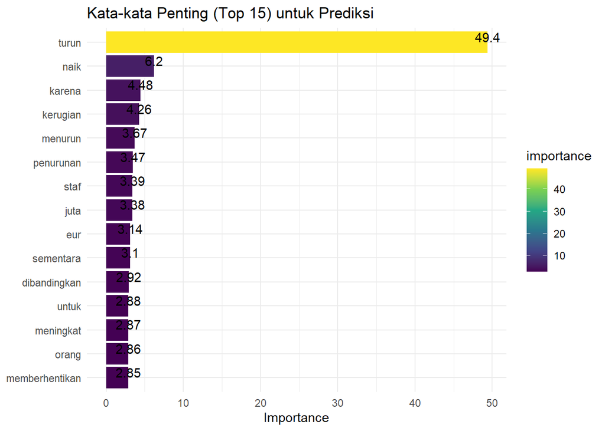

💡 Tingkat penting variabel menggambarkan seberapa besar kontribusi setiap kata terhadap prediksi. Semakin tinggi tingkat kepentingannya, semakin berpengaruh kata tersebut dalam proses pengambilan keputusan model.

# 6 Prediction Performance

## 6.1 Mengukur performa model pada dataset validasi

```r
# Mengukur performa model pada dataset validasi
valid_pred <- predict(model_rf, dtm_valid_mat)
valid_cm <- confusionMatrix(valid_pred, test_set$label)  # Ganti test_set dengan valid_data

# Menghitung akurasi, sensitivitas, spesifisitas, dan presisi pada dataset validasi
valid_accuracy <- valid_cm$overall["Accuracy"]
valid_sensitivity <- valid_cm$byClass["Sensitivity"]
valid_specificity <- valid_cm$byClass["Specificity"]
valid_precision <- valid_cm$byClass["Precision"]

# Melaporkan performa model pada dataset validasi
cat("Performa model pada dataset validasi:\n")
```

```
## Performa model pada dataset validasi:
```

```r
cat("Akurasi:", valid_accuracy, "\n")
```

```
## Akurasi: 0.866242
```

```r
cat("Sensitivitas:", valid_sensitivity, "\n")
```

```
## Sensitivitas: 0.6344828
```

```r
cat("Spesifisitas:", valid_specificity, "\n")
```

```
## Spesifisitas: 0.9693252
```

```r
cat("Presisi:", valid_precision, "\n\n")
```

```
## Presisi: 0.9019608
```

## 6.2 Mengukur performa model pada dataset uji (datatest)

```r
# Evaluasi model terbaik pada dataset uji
test_pred <- predict(model_rf, dtm_test_mat)
test_pred <- factor(test_pred, levels = levels(test_set$label))

# Jika level faktor test_pred dan test_data$label tidak sama, atur levelnya agar sama
levels(test_pred) <- levels(test_set$label)

test_cm <- confusionMatrix(test_pred, test_set$label)

# Menghitung akurasi, sensitivitas, spesifisitas, dan presisi pada dataset uji
test_accuracy <- test_cm$overall["Accuracy"]
test_sensitivity <- test_cm$byClass["Sensitivity"]
test_specificity <- test_cm$byClass["Specificity"]
test_precision <- test_cm$byClass["Precision"]

# Melaporkan performa model pada dataset uji
cat("Performa model pada dataset uji:\n")
```

```
## Performa model pada dataset uji:
```

```r
cat("Akurasi:", test_accuracy, "\n")
```

```
## Akurasi: 0.8789809
```

```r
cat("Sensitivitas:", test_sensitivity, "\n")
```

```
## Sensitivitas: 0.6758621
```

```r
cat("Spesifisitas:", test_specificity, "\n")
```

```
## Spesifisitas: 0.9693252
```

```r
cat("Presisi:", test_precision, "\n")
```

```
## Presisi: 0.9074074
```

## 6.3 Presdiksi kata yang tidak benar dalam datatest

Pada kode berikut, pengaturan jumlah kata yang muncul dalam wordcloud dilakukan dengan menggunakan fungsi `min.freq.` Argumen ini menentukan frekuensi minimum kata yang harus muncul agar dimasukkan ke dalam wordcloud. Kata-kata yang muncul dengan frekuensi lebih rendah dari nilai min.freq akan diabaikan.

```r
# Mengidentifikasi SMS yang diprediksi dengan tidak benar
misclassified_sms <- test_data[test_pred != test_set$label, "id_text"]

head(misclassified_sms)
```

```
## [1] "Antibodi , yang diberikan pada dosis berulang hingga 8 mg-kg , umumnya dapat ditoleransi dengan baik , dan karakteristik farmakokinetik BTT-1023 pada pasien psoriasis konsisten dengan yang diamati dalam penelitian yang diselesaikan sebelumnya pada pasien rheumatoid arthritis RA ."
## [2] "Di Swedia, terjadi kelebihan pasokan apotek."
## [3] "Citigroup, Inc (NYSE:C) telah mengumumkan bahwa bisnis Layanan Transaksi Global (GTS) telah diberikan mandat baru oleh Pohjola Bank Group yang berbasis di Finlandia."
## [4] "Laba sebelum pajak dari bisnis asuransi jiwa grup meningkat menjadi EUR 36 juta dari EUR 27 juta."
## [5] "Pada Januari-September 2009, pendapatan bunga bersih Grup meningkat menjadi EUR 112,4 juta dari EUR 74,3 juta pada Januari-September 2008."
## [6] "Penyedia sistem komunikasi data broadband Finlandia Teleste Oyj HEL : TLT1V mengatakan kemarin pihaknya kembali ke laba bersih EUR 2,7 juta USD 3,8 juta untuk sembilan bulan pertama tahun 2010 versus kerugian bersih EUR 579.000 untuk periode yang sama tahun 2009 ."
```

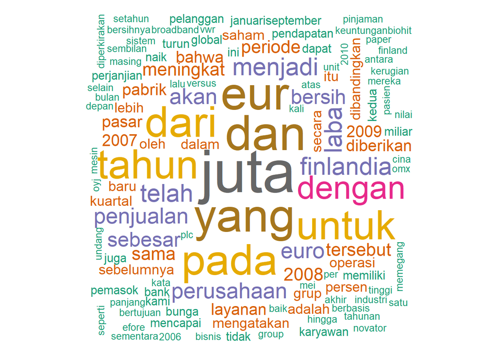

```r
# Buat Wordcloud dari teks yang diprediksi tidak benar
wordcloud(misclassified_sms, scale = c(5, 0.5), min.freq = 2, random.order = FALSE, colors = brewer.pal(8, "Dark2"))
```